# FinalAssignment_Solns

this could also indicate that there may be some outliers

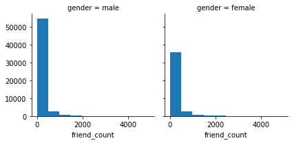

```python
g= sns.FacetGrid(facebook, col='gender')
g.map(plt.hist,'friend_count')
plt.show()
```

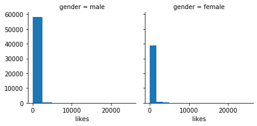

```python
g= sns.FacetGrid(facebook, col= 'gender')
g= g.map(plt.hist,'likes')
```

How are friendships typically initiated?

From the heat map there was a strong correlation between friendships initiated and friend count so i think this is a good place to start

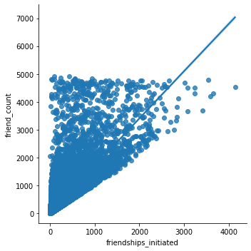

```python
g= sns.lmplot(data=facebook, x='friendships_initiated', y='friend_count' )
```

Consider the distribution of friend counts and likes.

#### From this plot we can see the presence of outliers.

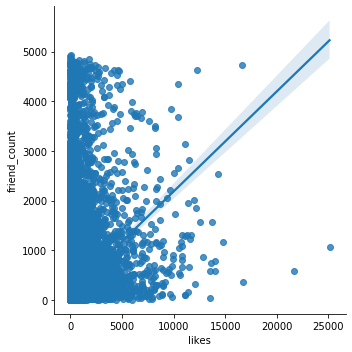

```python
g= sns.lmplot(data=facebook, x='likes', y='friend_count' )
```

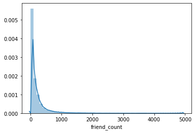

```python
ax = sns.distplot(facebook["friend_count"])
```

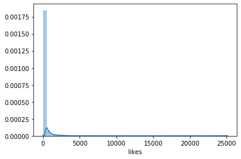

```python
ax = sns.distplot(facebook["likes"])
```

Remove outliers (values that are more than 2 standard deviations from the mean)

```python
describe=facebook['likes'].describe()
likesdata=facebook['likes']

std=facebook['likes'].std()
print("std: ",std)
cutoffstd2 = std * 2 # make cutoff as two times std
print(cutoffstd2)
mean=facebook['likes'].mean()
print("Mean: ",mean)

lower=mean-cutoffstd2 # 2 below the mean

upper=mean+cutoffstd2 # 2 above the mean

# identify outliers
Likes_outliers = [x for x in likesdata if x < lower or x > upper]
print('Identified outliers: %d' % len(Likes_outliers))

#print(describe)
Likes_outliers_removed = [x for x in likesdata if x >= lower and x <= upper]
print('Non-outlier observations: %d' % len(Likes_outliers_removed))
```

```
std:  572.2806808445049
1144.5613616890098
Mean:  156.07878549134875
Identified outliers: 2450
Non-outlier observations: 96553
```

```python
describe=facebook['friend_count'].describe()
friendcountdata=facebook['friend_count']

std=facebook['friend_count'].std()
print("std: ",std)
cutoffstd2 = std * 2 # make cutoff as two times std
print(cutoffstd2)
mean=facebook['friend_count'].mean()
print("Mean:", mean)
lower=mean-cutoffstd2 # 2 below the mean

upper=mean+cutoffstd2 # 2 above the mean

# identify outliers
Friend_Count_outliers = [x for x in friendcountdata if x < lower or x > upper]
print('Identified outliers: %d' % len(Friend_Count_outliers))

#print(describe)
Friend_Count_outliers_removed = [x for x in friendcountdata if x >= lower and x <= upper]
print('Non-outlier observations: %d' % len(Friend_Count_outliers_removed))
#facebook['friendoutliersrem']=Friend_Count_outliers_removed
```

```
std:  387.30422898757934
774.6084579751587
Mean: 196.3507873498783
Identified outliers: 3123
Non-outlier observations: 95880
```

```python
Q1=friendcountdata.quantile(0.25)
Q3=friendcountdata.quantile(0.75)
IQR=Q3-Q1
print(IQR)
```

```
175.0
```

Now analyse the distributions again, once as a whole and once split by gender.

How do the relationshiops look now?

#### here is the distribution of likes and friend count by gender with outliers removed

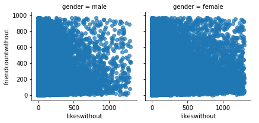

```python
g = sns.FacetGrid(facebook, col="gender")
g.map(plt.scatter, "likeswithout", "friendcountwithout", alpha=.7)
g.add_legend();
```

#### here is the distribution of likes and friend count with outliers removed

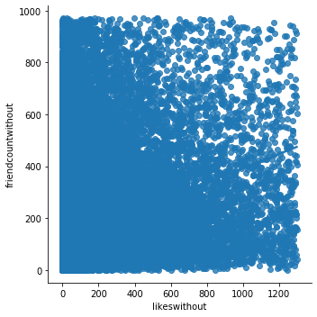

```python
g= sns.lmplot(data=facebook, x='likeswithout', y='friendcountwithout' )
```

## The following is the calculations to remove oultiers that are outside two std of the mean

### I added these as a columns to the table afterwards, friendcountwithout and likeswithout.

```python
friendcount=facebook.loc[:,['friend_count']]
z_scores = stats.zscore(friendcount)
#abs_z_scores = friendcount.abs(z_scores)
filtered_entries = (z_scores < 2).all(axis=1)
filteredfriendcount = friendcount[filtered_entries]
filteredfriendcount
facebook['friendcountwithout']=filteredfriendcount
facebook.describe()
```

|  | userid | age | dob_day | dob_year | dob_month | tenure | friend_count | friendships_initiated | likes | likes_received | mobile_likes | mobile_likes_received | www_likes | www_likes_received | friendcountwithout |
| --- | --- | --- | --- | --- | --- | --- | --- | --- | --- | --- | --- | --- | --- | --- | --- |
| count | 9.900300e+04 | 99003.000000 | 99003.000000 | 99003.000000 | 99003.000000 | 99001.000000 | 99003.000000 | 99003.000000 | 99003.000000 | 99003.000000 | 99003.000000 | 99003.000000 | 99003.000000 | 99003.000000 | 95880.000000 |
| mean | 1.597045e+06 | 37.280224 | 14.530408 | 1975.719776 | 6.283365 | 537.887375 | 196.350787 | 107.452471 | 156.078785 | 142.689363 | 106.116300 | 84.120491 | 49.962425 | 58.568831 | 142.011254 |
| std | 3.440592e+05 | 22.589748 | 9.015606 | 22.589748 | 3.529672 | 457.649874 | 387.304229 | 188.786951 | 572.280681 | 1387.919613 | 445.252985 | 839.889444 | 285.560152 | 601.416348 | 171.185072 |
| min | 1.000008e+06 | 13.000000 | 1.000000 | 1900.000000 | 1.000000 | 0.000000 | 0.000000 | 0.000000 | 0.000000 | 0.000000 | 0.000000 | 0.000000 | 0.000000 | 0.000000 | 0.000000 |
| 25% | 1.298806e+06 | 20.000000 | 7.000000 | 1963.000000 | 3.000000 | 226.000000 | 31.000000 | 17.000000 | 1.000000 | 1.000000 | 0.000000 | 0.000000 | 0.000000 | 0.000000 | 30.000000 |
| 50% | 1.596148e+06 | 28.000000 | 14.000000 | 1985.000000 | 6.000000 | 412.000000 | 82.000000 | 46.000000 | 11.000000 | 8.000000 | 4.000000 | 4.000000 | 0.000000 | 2.000000 | 78.000000 |
| 75% | 1.895744e+06 | 50.000000 | 22.000000 | 1993.000000 | 9.000000 | 675.000000 | 206.000000 | 117.000000 | 81.000000 | 59.000000 | 46.000000 | 33.000000 | 7.000000 | 20.000000 | 188.000000 |
| max | 2.193542e+06 | 113.000000 | 31.000000 | 2000.000000 | 12.000000 | 3139.000000 | 4923.000000 | 4144.000000 | 25111.000000 | 261197.000000 | 25111.000000 | 138561.000000 | 14865.000000 | 129953.000000 | 970.000000 |

```python
likesdata=facebook.loc[:,['likes']]
z_scores = stats.zscore(likesdata)
#abs_z_scores = friendcount.abs(z_scores)
filtered_likes = (z_scores < 2).all(axis=1)
LikesWithOutliersRemoved = likesdata[filtered_likes]
LikesWithOutliersRemoved
facebook['likeswithout']=LikesWithOutliersRemoved
facebook.describe()
```

|  | userid | age | dob_day | dob_year | dob_month | tenure | friend_count | friendships_initiated | likes | likes_received | mobile_likes | mobile_likes_received | www_likes | www_likes_received | friendcountwithout | likeswithout |
| --- | --- | --- | --- | --- | --- | --- | --- | --- | --- | --- | --- | --- | --- | --- | --- | --- |
| count | 9.900300e+04 | 99003.000000 | 99003.000000 | 99003.000000 | 99003.000000 | 99001.000000 | 99003.000000 | 99003.000000 | 99003.000000 | 99003.000000 | 99003.000000 | 99003.000000 | 99003.000000 | 99003.000000 | 95880.000000 | 96553.000000 |
| mean | 1.597045e+06 | 37.280224 | 14.530408 | 1975.719776 | 6.283365 | 537.887375 | 196.350787 | 107.452471 | 156.078785 | 142.689363 | 106.116300 | 84.120491 | 49.962425 | 58.568831 | 142.011254 | 87.636697 |
| std | 3.440592e+05 | 22.589748 | 9.015606 | 22.589748 | 3.529672 | 457.649874 | 387.304229 | 188.786951 | 572.280681 | 1387.919613 | 445.252985 | 839.889444 | 285.560152 | 601.416348 | 171.185072 | 190.744583 |
| min | 1.000008e+06 | 13.000000 | 1.000000 | 1900.000000 | 1.000000 | 0.000000 | 0.000000 | 0.000000 | 0.000000 | 0.000000 | 0.000000 | 0.000000 | 0.000000 | 0.000000 | 0.000000 | 0.000000 |
| 25% | 1.298806e+06 | 20.000000 | 7.000000 | 1963.000000 | 3.000000 | 226.000000 | 31.000000 | 17.000000 | 1.000000 | 1.000000 | 0.000000 | 0.000000 | 0.000000 | 0.000000 | 30.000000 | 1.000000 |
| 50% | 1.596148e+06 | 28.000000 | 14.000000 | 1985.000000 | 6.000000 | 412.000000 | 82.000000 | 46.000000 | 11.000000 | 8.000000 | 4.000000 | 4.000000 | 0.000000 | 2.000000 | 78.000000 | 10.000000 |
| 75% | 1.895744e+06 | 50.000000 | 22.000000 | 1993.000000 | 9.000000 | 675.000000 | 206.000000 | 117.000000 | 81.000000 | 59.000000 | 46.000000 | 33.000000 | 7.000000 | 20.000000 | 188.000000 | 70.000000 |
| max | 2.193542e+06 | 113.000000 | 31.000000 | 2000.000000 | 12.000000 | 3139.000000 | 4923.000000 | 4144.000000 | 25111.000000 | 261197.000000 | 25111.000000 | 138561.000000 | 14865.000000 | 129953.000000 | 970.000000 | 1300.000000 |

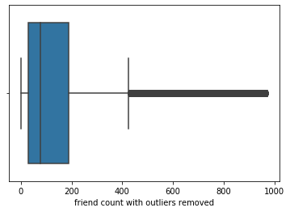

```python
ax = sns.boxplot(filteredfriendcount)
plt.xlabel('friend count with outliers removed')
```

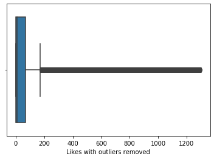

```python
ax=sns.boxplot(LikesWithOutliersRemoved)
plt.xlabel('Likes with outliers removed')
```

```
Boxplot showing likes with outliers
```

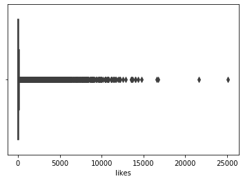

```python
ax=sns.boxplot(facebook['likes'])
print("Boxplot showing likes with outliers ")
```

```
box plot showing friend_count with outliers
```

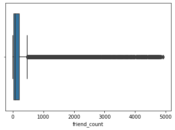

```python
ax = sns.boxplot(facebook["friend_count"])
print("box plot showing friend_count with outliers")
```

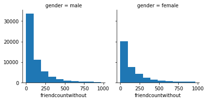

[output not shown]

```python
#g= sns.lmplot(x='likeswithout', y='friendcountwithout', hue='gender',data=facebook)
g= sns.FacetGrid(facebook, col='gender')
g.map(plt.hist,'friendcountwithout')
plt.show()
print("Histograms showing friend_count by gender with outliers removed")
```

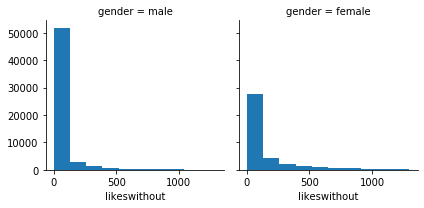

```
Histograms showing Likes by gender with outliers removed
```

```python
g= sns.FacetGrid(facebook, col='gender')
g.map(plt.hist,'likeswithout')
plt.show()
print("Histograms showing Likes by gender with outliers removed")
```

after removing the outliers, it is a little bit clearer as to the distribution for likes and friend count

```python
max_Male_likes=facebook['likeswithout'].loc[facebook['gender']=='male'].max()
```

```python
max_female_likes=facebook['likeswithout'].loc[facebook['gender']=='female'].max()
print("The highest number of likes when outliers are removed for male is: ", max_Male_likes, "and max number of likes for female is ",max_female_likes)
print("In comparison the highest number of likes with outliers included was: ", facebook['likes'].loc[facebook['gender']=='male'].max(),"for male and ", facebook['likes'].loc[facebook['gender']=='female'].max(),"for female")
```

```
The highest number of likes when outliers are removed for male is:  1299.0 and max number of likes for female is  1300.0
In comparison the highest number of likes with outliers included was:  25111 for male and  16732 for female
```

```python
male=facebook['userid'].loc[facebook['gender']=='male'].count()
female=facebook['userid'].loc[facebook['gender']=='female'].count()
print("the count of males in the dataset is: ", male , "the count of females in the dataset is: ", female)
diff=male-female
print("while we can see that males have more likes, the data is slightly biased as it does contain ", diff, "more males than females, ")
print("Out of a total of: ",facebook['userid'].count())
```

```
the count of males in the dataset is:  58574 the count of females in the dataset is:  40254
while we can see that males have more likes, the data is slightly biased as it does contain  18320 more males than females,
Out of a total of:  99003
```